# NSE groepsgewijze significantie-berekeningen

Dit is een [R Markdown](http://rmarkdown.rstudio.com) Notebook waarin voor de Nationale Student Enquete (NSE) groepsgewijze T-testen worden uitgerekend. Dit bestaat proces bestaat uit de volgende stappen:

1. Laden benodigde R-bibliotheken
2. Inladen NSE benchmark bestand
3. Groepen definiëren - HU totaal - Benchmark R6 - Benchmark A (alles)
4. Kijken naar verdeling van data binnen groepen
5. T-testen uitvoeren
6. Resultaten wegschrijven

# 0. Laden R-bibliotheken

# 1. Inladen NSE benchmark bestand (clean data)

```r
load("~/research-drive/M21033303_DenA (Projectfolder)/DA_Onderzoek/2021nse/data_in/NSE2021 nse_benchmark_clean.RData")
head(nse_benchmark_clean,10)
```

|  | UniekNummer | Jaar | Weegfactor | BrinActueel | BrinNaamActueel | Brin | BrinNaam | CrohoActueel | CrohoNaamActueel | Croho | CrohoNaam | Locatie | CrohoSector | CrohoSectorNaam | SoortHo | BaMa | Gemeentecode | Stedelijkheid | Landsdeel | Fixus | Decentraal | Bekostiging | Opleidingsvorm3 | Opleidingsvorm2 | BrinVolgnummerActueel | BrinVolgnummer | TypeStudent | TEVREDENHEIDALGEMEEN_01 | TEVREDENHEIDALGEMEEN_02 | … |
| --- | --- | --- | --- | --- | --- | --- | --- | --- | --- | --- | --- | --- | --- | --- | --- | --- | --- | --- | --- | --- | --- | --- | --- | --- | --- | --- | --- | --- | --- | --- |
| 65 | 101504 | 2021 | 0.6938545 | 00IC | Katholieke PABO Zwolle | 00IC | Katholieke PABO Zwolle | 34808 | B Opleiding tot leraar Basisonderwijs | 34808 | B Opleiding tot leraar Basisonderwijs | Zwolle | 1 | Onderwijs | 1 | 1 | 193 | 2 | 2 | 0 | 0 | 1 | 1 | 1 | 0 | 0 | 1 | 5 | 4 | … |
| 66 | 104675 | 2021 | 0.6938545 | 00IC | Katholieke PABO Zwolle | 00IC | Katholieke PABO Zwolle | 34808 | B Opleiding tot leraar Basisonderwijs | 34808 | B Opleiding tot leraar Basisonderwijs | Zwolle | 1 | Onderwijs | 1 | 1 | 193 | 2 | 2 | 0 | 0 | 1 | 1 | 1 | 0 | 0 | 1 | 3 | 4 | … |
| 67 | 110199 | 2021 | 0.6938545 | 00IC | Katholieke PABO Zwolle | 00IC | Katholieke PABO Zwolle | 34808 | B Opleiding tot leraar Basisonderwijs | 34808 | B Opleiding tot leraar Basisonderwijs | Zwolle | 1 | Onderwijs | 1 | 1 | 193 | 2 | 2 | 0 | 0 | 1 | 1 | 1 | 0 | 0 | 1 | 3 | 3 | … |
| 68 | 111750 | 2021 | 0.6938545 | 00IC | Katholieke PABO Zwolle | 00IC | Katholieke PABO Zwolle | 34808 | B Opleiding tot leraar Basisonderwijs | 34808 | B Opleiding tot leraar Basisonderwijs | Zwolle | 1 | Onderwijs | 1 | 1 | 193 | 2 | 2 | 0 | 0 | 1 | 1 | 1 | 0 | 0 | 1 | 5 | 4 | … |
| 69 | 111887 | 2021 | 0.6938545 | 00IC | Katholieke PABO Zwolle | 00IC | Katholieke PABO Zwolle | 34808 | B Opleiding tot leraar Basisonderwijs | 34808 | B Opleiding tot leraar Basisonderwijs | Zwolle | 1 | Onderwijs | 1 | 1 | 193 | 2 | 2 | 0 | 0 | 1 | 1 | 1 | 0 | 0 | 1 | 4 | 4 | … |
| 70 | 114762 | 2021 | 0.6938545 | 00IC | Katholieke PABO Zwolle | 00IC | Katholieke PABO Zwolle | 34808 | B Opleiding tot leraar Basisonderwijs | 34808 | B Opleiding tot leraar Basisonderwijs | Zwolle | 1 | Onderwijs | 1 | 1 | 193 | 2 | 2 | 0 | 0 | 1 | 1 | 1 | 0 | 0 | 1 | 2 | 3 | … |
| 71 | 126531 | 2021 | 0.6938545 | 00IC | Katholieke PABO Zwolle | 00IC | Katholieke PABO Zwolle | 34808 | B Opleiding tot leraar Basisonderwijs | 34808 | B Opleiding tot leraar Basisonderwijs | Zwolle | 1 | Onderwijs | 1 | 1 | 193 | 2 | 2 | 0 | 0 | 1 | 1 | 1 | 0 | 0 | 1 | 5 | 4 | … |
| 72 | 129361 | 2021 | 0.6938545 | 00IC | Katholieke PABO Zwolle | 00IC | Katholieke PABO Zwolle | 34808 | B Opleiding tot leraar Basisonderwijs | 34808 | B Opleiding tot leraar Basisonderwijs | Zwolle | 1 | Onderwijs | 1 | 1 | 193 | 2 | 2 | 0 | 0 | 1 | 1 | 1 | 0 | 0 | 1 | 4 | 4 | … |
| 73 | 129705 | 2021 | 0.6938545 | 00IC | Katholieke PABO Zwolle | 00IC | Katholieke PABO Zwolle | 34808 | B Opleiding tot leraar Basisonderwijs | 34808 | B Opleiding tot leraar Basisonderwijs | Zwolle | 1 | Onderwijs | 1 | 1 | 193 | 2 | 2 | 0 | 0 | 1 | 1 | 1 | 0 | 0 | 1 | 3 | 4 | … |
| 74 | 130490 | 2021 | 0.6938545 | 00IC | Katholieke PABO Zwolle | 00IC | Katholieke PABO Zwolle | 34808 | B Opleiding tot leraar Basisonderwijs | 34808 | B Opleiding tot leraar Basisonderwijs | Zwolle | 1 | Onderwijs | 1 | 1 | 193 | 2 | 2 | 0 | 0 | 1 | 1 | 1 | 0 | 0 | 1 | 4 | 3 | … |

# 2. Groepen definiëren

Voor de analyse zijn nodig de vergelijkingsgroepen: HU, R6 (behalve HU) en alles (behalve HU). Hiervoor wordt de volgende groepering aangebracht in de data: HU, R5, O (waarbij O staat voor ‘overig’). Groep ‘alles behalve HU’ kan nu gemaakt worden door de groeperingen ‘R5’ en ‘O’ te combineren.

Vervolgens is er een gelaagdheid aan granulariteit waarop de groepen met elkaar vergeleken worden:

- Totaal
- Totaal variant (d.w.z.: voltijd, deeltijd, duaal)
- Opleiding totaal
- Opleiding variant

```r
groepHU <- "Hogeschool Utrecht"
groepR5 <- c("Hogeschool van Amsterdam", "De Haagse Hogeschool", "Hogeschool INHOLLAND", "Hogeschool Leiden", "Hogeschool Rotterdam")
varianttypes <- unique(nse_benchmark_clean$Opleidingsvorm3)
```

Aanmaken van een extra kolom (‘Groep’) in de dataset waarin de groep met een lettercode wordt wordt aangegeven.

```r
nse_benchmark_clean <- nse_benchmark_clean %>% add_column(Groep = NA) #lege kolom toevoegen
nse_benchmark_clean$Groep[nse_benchmark_clean$BrinNaamActueel == groepHU] <- "HU"
for (i in 1:length(groepR5))
{
  nse_benchmark_clean$Groep[nse_benchmark_clean$BrinNaamActueel == groepR5[i]] <- "R5"
}
nse_benchmark_clean$Groep[is.na(nse_benchmark_clean$Groep)] <- "O"

cat("Samenvatting student-aantallen per groep:")
```

```
## Samenvatting student-aantallen per groep:
```

```r
table(nse_benchmark_clean$Groep)
```

```
##
##     HU      O     R5
##  14363 134583  54806
```

# 3. NSE Vragen definities

De kolommen waarin de vraagresponses zich bevinden moeten aangegeven worden.

```r
Nvragen = length(vec_NSEvragen)
Neerste = min(vec_NSEvragen)
cat("De volgende ",toString(Nvragen)," vragen zijn opgenomen in deze significantie berekening:")
```

```
## De volgende  57  vragen zijn opgenomen in deze significantie berekening:
```

```r
NSEvragen
```

```
##  [1] "TEVREDENHEIDALGEMEEN_01"    "TEVREDENHEIDALGEMEEN_02"
##  [3] "TEVREDENHEIDALGEMEEN_03"    "TEVREDENHEIDALGEMEEN_04"
##  [5] "TEVREDENHEIDALGEMEEN_05"    "TEVREDENHEIDALGEMEEN_06"
##  [7] "TEVREDENHEIDALGEMEEN_07"    "TEVREDENHEIDALGEMEEN_08"
##  [9] "TEVREDENHEIDALGEMEEN_09"    "TEVREDENHEIDALGEMEEN_10"
## [11] "TEVREDENHEIDALGEMEEN_11"    "TEVREDENHEIDALGEMEEN_12"
## [13] "OPNIEUWKIEZEN"              "INHOUDOPZET_THEMA"
## [15] "INHOUDOPZET_01"             "INHOUDOPZET_02"
## [17] "INHOUDOPZET_03"             "INHOUDOPZET_04"
## [19] "INHOUDOPZET_05"             "INHOUDOPZET_06"
## [21] "INHOUDOPZET_07"             "INHOUDOPZET_08"
## [23] "STUDIEDRUK_01"              "AANSLUITING_THEMA"
## [25] "AANSLUITING_01"             "AANSLUITING_02"
## [27] "DOCENTEN_THEMA"             "DOCENTEN_01"
## [29] "DOCENTEN_02"                "DOCENTEN_03"
## [31] "DOCENTEN_04"                "DOCENTEN_05"
## [33] "DOCENTEN_06"                "DOCENTEN_07"
## [35] "DOCENTEN_08"                "ENGELS_01"
## [37] "BEGELEIDING_SELECTIE"       "BEGELEIDING_THEMA"
## [39] "BEGELEIDING_01"             "BEGELEIDING_02"
## [41] "TOETSINGBEOORDELING_THEMA"  "TOETSINGBEOORDELING_01"
## [43] "TOETSINGBEOORDELING_02"     "TOETSINGBEOORDELING_03"
## [45] "TOETSINGBEOORDELING_04"     "TOETSINGBEOORDELING_05"
## [47] "TOETSINGBEOORDELING_06"     "BETROKKENHEIDCONTACT_THEMA"
## [49] "BETROKKENHEIDCONTACT_01"    "BETROKKENHEIDCONTACT_02"
## [51] "BETROKKENHEIDCONTACT_03"    "BETROKKENHEIDCONTACT_04"
## [53] "BETROKKENHEIDCONTACT_05"    "BETROKKENHEIDCONTACT_06"
## [55] "BETROKKENHEIDCONTACT_07"    "BETROKKENHEIDCONTACT_08"
## [57] "BETROKKENHEIDCONTACT_09"
```

# 4. Samenvattende statistieken (exploratieve data analyse)

- Kijken naar outliers
- Kijken naar verdeling van data binnen groepen

```r
vraag <- 5
cat("Dit is de vraag: ", NSEvragen[vraag])
```

```
## Dit is de vraag:  TEVREDENHEIDALGEMEEN_05
```

```r
HUscores <- nse_benchmark_clean[nse_benchmark_clean$Groep == "HU",vec_NSEvragen[vraag]]
R5scores <- nse_benchmark_clean[nse_benchmark_clean$Groep == "R5",vec_NSEvragen[vraag]]
Allescores <- nse_benchmark_clean[nse_benchmark_clean$Groep == "O" | nse_benchmark_clean$Groep == "R5", vec_NSEvragen[vraag]]

describeBy(nse_benchmark_clean[,vec_NSEvragen[vraag]], nse_benchmark_clean$Groep)
```

```
##
##  Descriptive statistics by group
## group: HU
##    vars    n mean   sd median trimmed  mad min max range  skew kurtosis   se
## X1    1 3322  3.7 0.91      4    3.78 1.48   1   5     4 -0.68     0.33 0.02
## ------------------------------------------------------------
## group: O
##    vars     n mean   sd median trimmed  mad min max range  skew kurtosis   se
## X1    1 17112 3.76 0.89      4    3.84 1.48   1   5     4 -0.65      0.3 0.01
## ------------------------------------------------------------
## group: R5
##    vars    n mean   sd median trimmed  mad min max range skew kurtosis   se
## X1    1 6199 3.61 0.93      4    3.67 1.48   1   5     4 -0.6     0.13 0.01
```

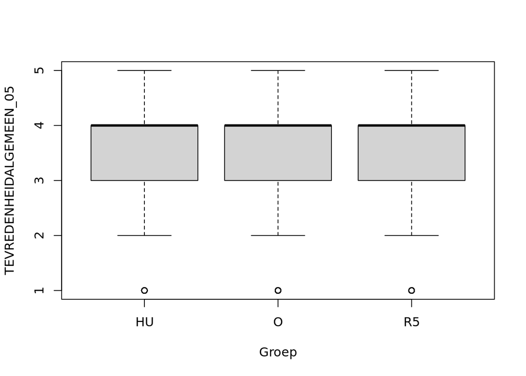

```r
boxplot(nse_benchmark_clean[,vec_NSEvragen[vraag]]~nse_benchmark_clean$Groep, xlab = "Groep", ylab = NSEvragen[vraag])
```

```r
table(Allescores)
```

```
## Allescores
##     1     2     3     4     5
##   384  1956  5496 11377  4098
```

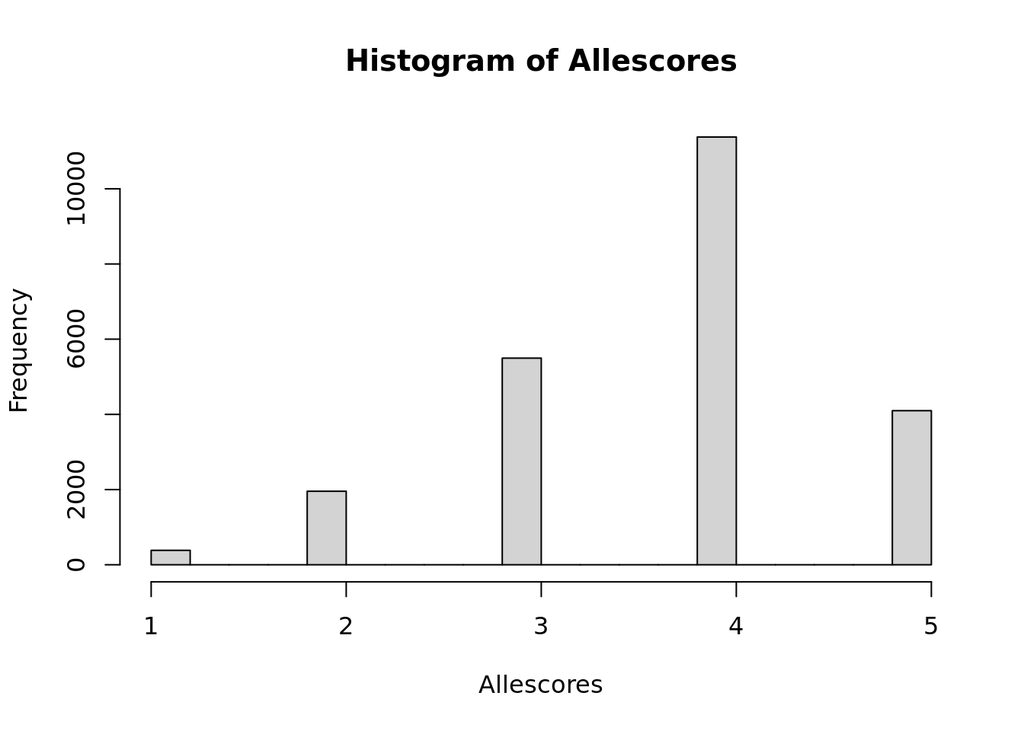

```r
hist(Allescores)
```

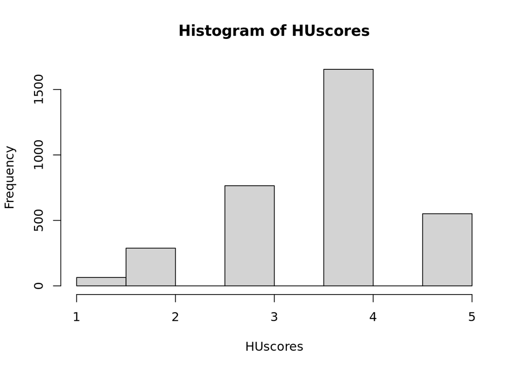

```r
hist(HUscores)
```

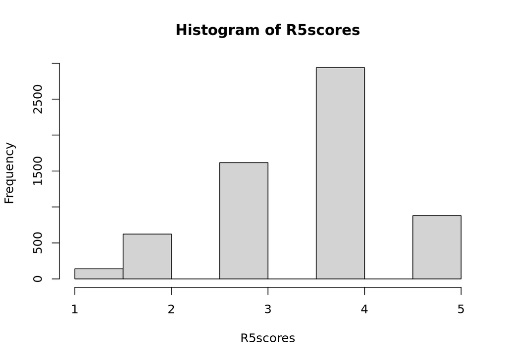

```r
hist(R5scores)
```

# 5. Samenvattende statistieken

```r
HUscores <- nse_benchmark_clean[nse_benchmark_clean$Groep == "HU",vec_NSEvragen]
R5scores <- nse_benchmark_clean[nse_benchmark_clean$Groep == "R5",vec_NSEvragen]
Allescores <- nse_benchmark_clean[nse_benchmark_clean$Groep == "O" | nse_benchmark_clean$Groep == "R5", vec_NSEvragen]

describeBy(nse_benchmark_clean[,vec_NSEvragen], nse_benchmark_clean$Groep)
```

```
##
##  Descriptive statistics by group
## group: HU
##                            vars     n mean   sd median trimmed  mad min max
## TEVREDENHEIDALGEMEEN_01       1 14363 3.55 0.90   4.00    3.60 0.00   1   5
## TEVREDENHEIDALGEMEEN_02       2 14075 3.70 0.84   4.00    3.76 0.00   1   5
## TEVREDENHEIDALGEMEEN_03       3 14075 3.65 0.84   4.00    3.70 0.00   1   5
## TEVREDENHEIDALGEMEEN_04       4 10753 3.50 0.90   4.00    3.53 1.48   1   5
## TEVREDENHEIDALGEMEEN_05       5  3322 3.70 0.91   4.00    3.78 1.48   1   5
## TEVREDENHEIDALGEMEEN_06       6 13944 3.70 0.89   4.00    3.77 1.48   1   5
## TEVREDENHEIDALGEMEEN_07       7 13944 3.25 0.98   3.00    3.29 1.48   1   5
## TEVREDENHEIDALGEMEEN_08       8 13944 3.45 0.91   4.00    3.48 1.48   1   5
## TEVREDENHEIDALGEMEEN_09       9 13774 3.40 0.92   4.00    3.45 1.48   1   5
## TEVREDENHEIDALGEMEEN_10      10 13774 3.58 0.89   4.00    3.63 1.48   1   5
## TEVREDENHEIDALGEMEEN_11      11  5549 3.52 0.97   4.00    3.56 1.48   1   5
## TEVREDENHEIDALGEMEEN_12      12 13774 3.93 0.88   4.00    4.00 1.48   1   5
## OPNIEUWKIEZEN                13 13631 3.65 1.14   4.00    3.76 1.48   1   5
## INHOUDOPZET_THEMA            14 13075 3.59 0.61   3.62    3.62 0.56   1   5
## INHOUDOPZET_01               15 13394 3.79 0.85   4.00    3.85 0.00   1   5
## INHOUDOPZET_02               16 13394 3.64 0.82   4.00    3.69 0.00   1   5
## INHOUDOPZET_03               17 13394 3.70 0.83   4.00    3.75 0.00   1   5
## INHOUDOPZET_04               18 13394 3.52 0.87   4.00    3.56 1.48   1   5
## INHOUDOPZET_05               19 13075 3.59 0.92   4.00    3.63 1.48   1   5
## INHOUDOPZET_06               20 13075 3.48 0.94   4.00    3.51 1.48   1   5
## INHOUDOPZET_07               21 13075 3.66 0.85   4.00    3.72 0.00   1   5
## INHOUDOPZET_08               22 13075 3.32 1.02   3.00    3.32 1.48   1   5
## STUDIEDRUK_01                23 13000 3.38 0.74   3.00    3.38 0.00   1   5
## AANSLUITING_THEMA            24 12663 3.57 0.79   3.50    3.60 0.74   1   5
## AANSLUITING_01               25 12663 3.64 0.87   4.00    3.70 1.48   1   5
## AANSLUITING_02               26 12663 3.50 0.97   4.00    3.54 1.48   1   5
## DOCENTEN_THEMA               27 12326 3.71 0.66   3.75    3.74 0.56   1   5
## DOCENTEN_01                  28 12433 3.69 0.94   4.00    3.77 1.48   1   5
## DOCENTEN_02                  29 12433 3.67 0.81   4.00    3.70 0.00   1   5
## DOCENTEN_03                  30 12433 3.99 0.79   4.00    4.05 0.00   1   5
## DOCENTEN_04                  31 12433 3.93 0.82   4.00    3.99 0.00   1   5
## DOCENTEN_05                  32 12326 3.52 0.92   4.00    3.56 1.48   1   5
## DOCENTEN_06                  33 12326 3.34 0.97   3.00    3.35 1.48   1   5
## DOCENTEN_07                  34 12326 3.69 0.81   4.00    3.72 0.00   1   5
## DOCENTEN_08                  35 12326 3.84 0.89   4.00    3.92 0.00   1   5
## ENGELS_01                    36  3833 3.48 1.05   4.00    3.53 1.48   1   5
```

[output cut: 300 more lines]

```
## TOETSINGBEOORDELING_02         4 -0.60    -0.04 0.00
## TOETSINGBEOORDELING_03         4 -0.81     0.78 0.00
## TOETSINGBEOORDELING_04         4 -0.77     0.77 0.00
## TOETSINGBEOORDELING_05         4 -0.80     0.92 0.00
## TOETSINGBEOORDELING_06         4 -0.50    -0.19 0.00
## BETROKKENHEIDCONTACT_THEMA     4 -0.62     1.16 0.00
## BETROKKENHEIDCONTACT_01        4 -0.77     0.41 0.00
## BETROKKENHEIDCONTACT_02        4 -0.63     0.31 0.00
## BETROKKENHEIDCONTACT_03        4 -1.04     1.62 0.00
## BETROKKENHEIDCONTACT_04        4 -0.77     0.59 0.00
## BETROKKENHEIDCONTACT_05        4 -0.65     0.40 0.00
## BETROKKENHEIDCONTACT_06        4 -0.59     0.01 0.00
## BETROKKENHEIDCONTACT_07        4 -0.55    -0.09 0.00
## BETROKKENHEIDCONTACT_08        4 -0.62     0.38 0.00
## BETROKKENHEIDCONTACT_09        4 -0.81     0.65 0.00
```

# 6. Significanties uitrekenen

Voor de vergelijkingen tussen groepen wordt de Welch T-test gebruikt: deze doet geen aannames over gelijke varianties tussen de testgroepen. Doordat je groepen met verschillende groepsgroottes vergelijkt is het namelijk mogelijk dat de varianties tussen groepen verschilt.

```r
#Bijeen zoeken van responsdata per groep
HUscores <- nse_benchmark_clean[nse_benchmark_clean$Groep == "HU",]
R5scores <- nse_benchmark_clean[nse_benchmark_clean$Groep == "R5",]
Allescores <- nse_benchmark_clean[nse_benchmark_clean$Groep == "O" | nse_benchmark_clean$Groep == "R5",]
p_HUR5 <- rep(NA, Nvragen)
p_HUAlle <- rep(NA, Nvragen)
p_HUR5_variant <- rep(NA, Nvragen)
gem_HU <- rep(NA, Nvragen)
gem_R5 <- rep(NA, Nvragen)
gem_Alle <- rep(NA, Nvragen)
diff_HUR5 <- rep(NA, Nvragen)
diff_HUAlle <- rep(NA, Nvragen)

Ncor <- Neerste + 1 #correctiefactor zodat index voor het vullen van p waardes op 1 begint en niet op 28

p_HUR5_variant[1] <- t.test(HUscores[HUscores$Opleidingsvorm3 == varianttypes[1],28],        R5scores[R5scores$Opleidingsvorm3 == varianttypes[1],28])$p.value

#Voor elke NSEvraag de respons tussen groepen vergelijken en p waarde opslaan
for (i_vraag in vec_NSEvragen)
  {
  p_HUR5[i_vraag-Ncor]   <- t.test(HUscores[,i_vraag], R5scores[,i_vraag])$p.value
  p_HUAlle[i_vraag-Ncor] <- t.test(HUscores[,i_vraag], Allescores[,i_vraag]
                                   )$p.value
  gem_HU[i_vraag-Ncor]  <- t.test(HUscores[,i_vraag], R5scores[,i_vraag])$estimate[1]
  gem_R5[i_vraag-Ncor]   <- t.test(HUscores[,i_vraag], R5scores[,i_vraag])$estimate[2]
  gem_Alle[i_vraag-Ncor] <- t.test(HUscores[,i_vraag], Allescores[,i_vraag]
                                   )$estimate[2]

  diff_HUR5[i_vraag-Ncor]   <- mean(HUscores[,i_vraag], na.rm = TRUE) -
                             mean(R5scores[,i_vraag], na.rm = TRUE)
  diff_HUAlle[i_vraag-Ncor] <- mean(HUscores[,i_vraag], na.rm = TRUE) -
                               mean(Allescores[,i_vraag], na.rm = TRUE)
}
```

# 6B. Multiple testing correctie p-waarden

Op het niveau van HU totaal worden in totaal 57 testen uitgevoerd onderverdeeld in 16 verschillende thema’s, zie ook het bestand docs/NSE2021 MultipleTesting. Op het niveau van HU totaal zijn er dus 16 hypotheses die getest worden (sommige middels deel-vragen), namelijk voor elk van deze thema’s is de nul-hypothese: “Het gemiddelde antwoord van HU studenten voor deze vraag is gelijk aan die van de R5 studenten”. Correctie voor deze multiple-testing vindt plaats via de [Benjamini-Hochberg FDR correctie](https://en.wikipedia.org/wiki/False_discovery_rate#Benjamini%E2%80%93Hochberg_procedure), en dan de Benjamini-Yekutieli (BY) variant. Deze variant controleert ook voor testen die mogelijk positief met elkaar gecorrigeerd zijn (bijvoorbeeld de verschillende docent-deelvragen). Zie ook hier

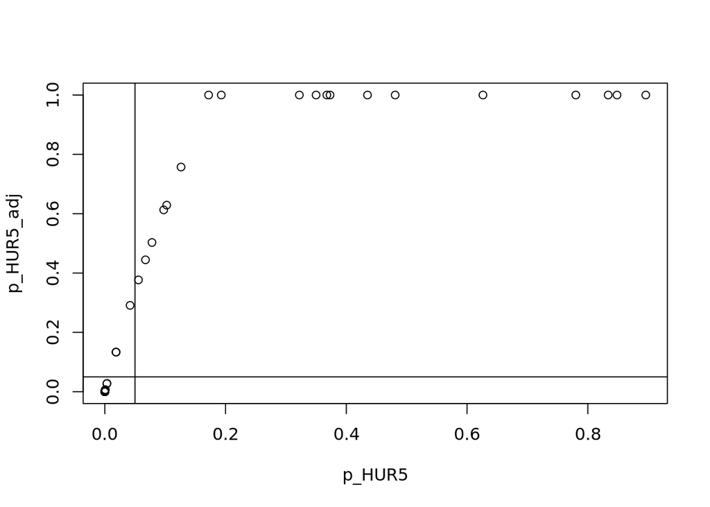

```r
p_HUR5_adj <- p.adjust(p_HUR5, method = "BY")
p_HUAlle_adj <- p.adjust(p_HUAlle, method = 'BY')
# Bekijken van verschuiving oorspronkelijke p en p_adj
plot(p_HUR5, p_HUR5_adj); abline(h = 0.05, v=0.05)
```

```r
rm(p_HUR5, p_HUAlle)
```

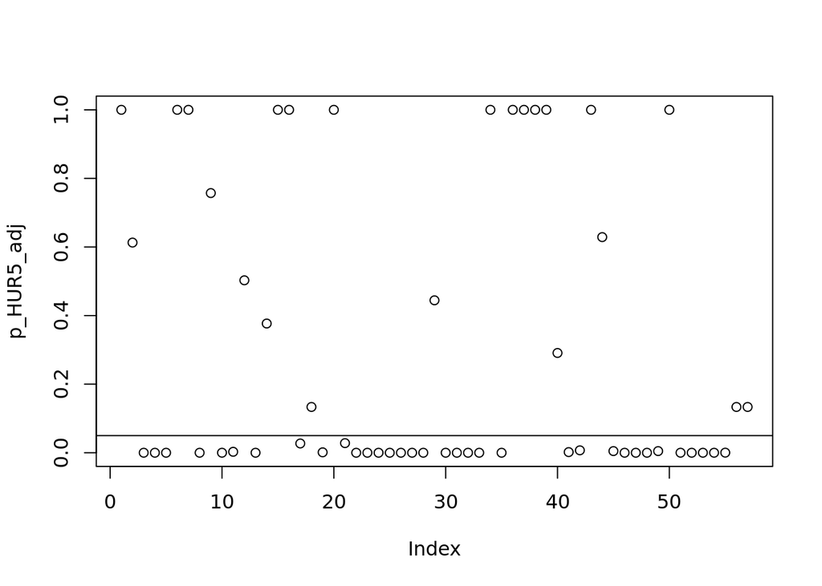

```r
plot(p_HUR5_adj)
abline(h = 0.05)
```

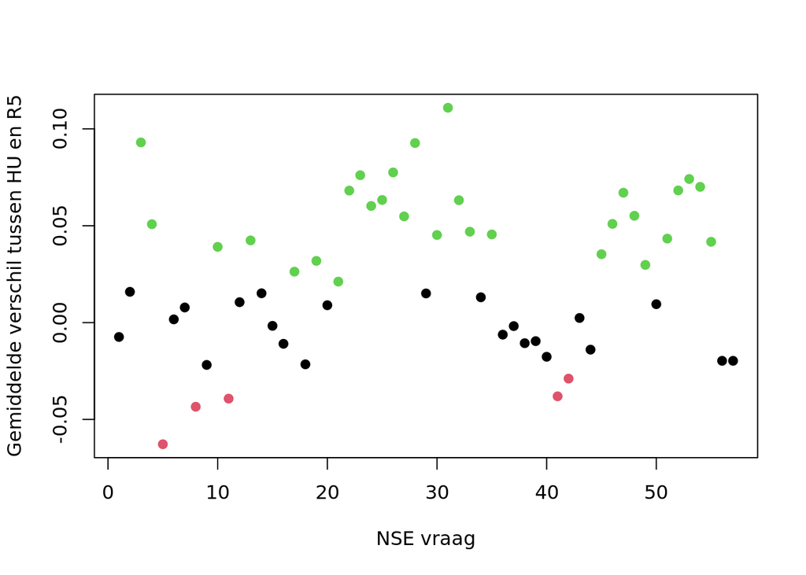

```r
groepering <- ifelse(diff_HUR5 > 0 & p_HUR5_adj < 0.05, 3, ifelse(diff_HUR5 < 0 & p_HUR5_adj < 0.05, 2, 1))
plot(diff_HUR5, col = groepering, pch = 19, xlab = "NSE vraag", ylab = "Gemiddelde verschil tussen HU en R5")
```

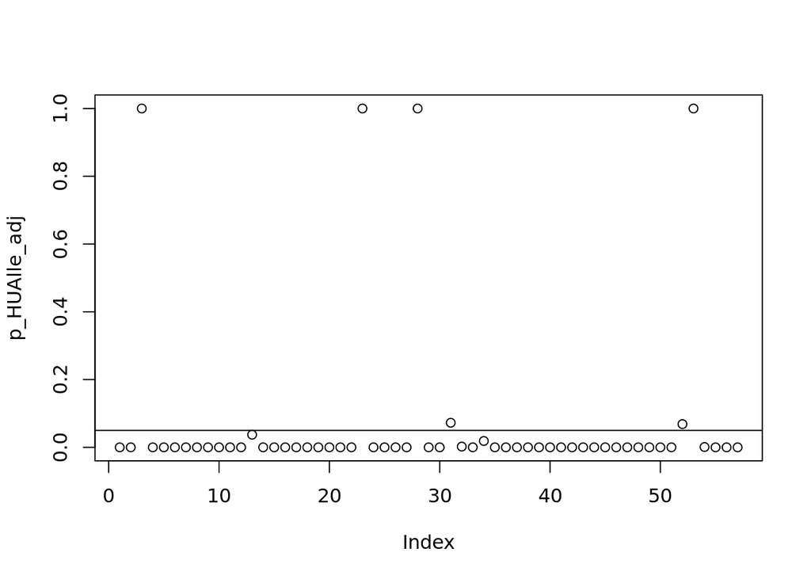

```r
plot(p_HUAlle_adj)
abline(h = 0.05)
```

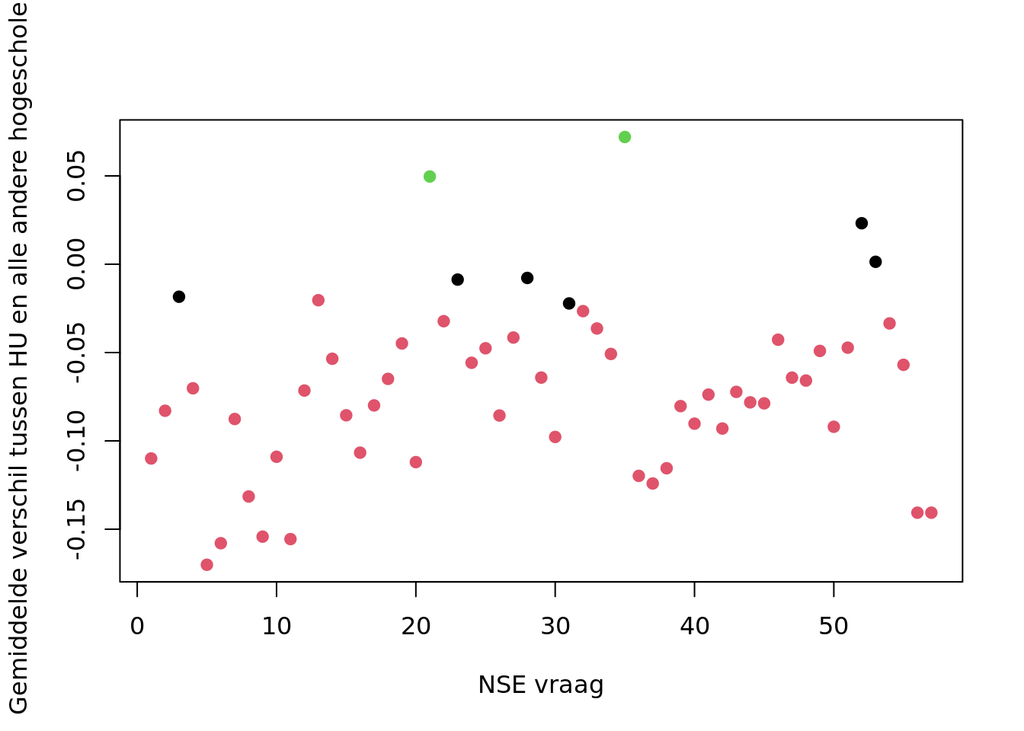

```r
groepering <- ifelse(diff_HUAlle > 0 & p_HUAlle_adj < 0.05, 3, ifelse(diff_HUAlle < 0 & p_HUAlle_adj < 0.05, 2, 1))
plot(diff_HUAlle, col = groepering, pch = 19, xlab = "NSE vraag", ylab = "Gemiddelde verschil tussen HU en alle andere hogescholen")
```

# 7. Exporteren p waardes

```r
nse_significanties <- data.frame(Opleidingsvorm3=character(),
                                 CrohoActueel   =character(),
                                 Vraag          =character(),
                                 Benchmark      =character(),
                                 p              =double(),
                                 Niveau         =character(),
                                 HUgem          =double(),
                                 Benchmarkgem   =double())
```

```r
temp1 <- data.frame(Opleidingsvorm3  = rep("Totaal",Nvragen),
                   CrohoActueel      = rep("Totaal",Nvragen),
                   Vraag             = NSEvragen,
                   Benchmark         = rep("R5",Nvragen),
                   p                 = p_HUR5_adj,
                   Niveau            = rep("HU",Nvragen),
                   HUgem             = gem_HU,
                   Benchmarkgem      = gem_R5)

temp2 <- data.frame(Opleidingsvorm3  = rep("Totaal",Nvragen),
                   CrohoActueel      = rep("Totaal",Nvragen),
                   Vraag             = NSEvragen,
                   Benchmark         = rep("Alle",Nvragen),
                   p                 = p_HUAlle_adj,
                   Niveau            = rep("HU",Nvragen),
                   HUgem             = gem_HU,
                   Benchmarkgem      = gem_Alle)
nse_significanties <- rbind(nse_significanties, temp1, temp2); rm(temp1, temp2)
```

```r
write.csv2(nse_significanties, file = "~/research-drive/M21033303_DenA (Projectfolder)/DA_Onderzoek/2021nse/data_uit/NSEsignificantietabel.csv")
```